# Introduction to DElegate

Christoph Hafemeister

2023-03-28

```r
library(dplyr)
library(Seurat)
```

```r
library(DElegate)
library(ggplot2)
library(ggrepel)
```

## Introduction

`DElegate` is an R package that allows bulk RNA-seq differential expression methods to be used with single-cell data. It is a light wrapper around [`DESeq2`](https://doi.org/doi:10.18129/B9.bioc.DESeq2), [`edgeR`](https://doi.org/doi:10.18129/B9.bioc.edgeR), and [`limma`](https://doi.org/doi:10.18129/B9.bioc.limma), similar to the [`Libra`](https://github.com/neurorestore/Libra) package. In contrast to `Libra`, `DElegate` focuses on a few DE methods and will assign cells to pseudo-replicates if no true replicates are available.

All `DElegate` functionality is contained in one function - `findDE()`. It has one mandatory input argument: `object`, which may be of class

- `Seurat` - the count matrix will be extracted from the `'RNA'` assay
- `SingleCellExperiment` - the count matrix will be extracted via `counts()`
- `dgCMatrix` - sparse matrix of the `Matrix` package
- `matrix`

To indicate the cell group memberships, you have several options, depending on input type:

- `Seurat` - in the object via `Idents(object)`, or use the `group_column` argument
- `SingleCellExperiment` - in the object via `colLables(object)`, or use the `group_column` argument
- `dgCMatrix`, or `matrix` - use the `meta_data` and `group_column` arguments

`DElegate` uses bulk RNA-seq DE methods and relies on replicates. If no true replicates are available, it assigns cells to pseudo-replicates. However, if replicates are available in the input, the `replicate_column` argument can be used to indicate where to find the labels.

To tell `findDE()` which cell groups to compare, use the `compare` argument. We provide several ways to set up the comparisons that will be tested:

- `'each_vs_rest'`, the default, does multiple comparisons, one per group vs all remaining cells
- `'all_vs_all'`, also does multiple comparisons, covering all group pairs
- a length one character vector, e.g. `'MONOCYTES'`, does one comparison between that group and the remaining cells
- a length two character vector, e.g. `c('T CELLS', 'B CELLS')`, does one comparison between those two groups
- a list of length two, e.g. `list(c('T CELLS', 'B CELLS'), c('MONOCYTES'))`, does one comparison after combining groups

Finally, there are currently three DE methods supported

- `'edger'` uses `edgeR::glmQLFit`
- `'deseq'` uses `DESeq2::DESeq(test = 'Wald')`
- `'limma'` uses `limma::eBayes(trend = TRUE, robust = TRUE)`

For complete details, consult the package documentation: `?DElegate::findDE`

In the examples below, we use a Seurat object `s` with cell type labels in the identity slot (`Idents(s)`).

```r
show(s)
```

```
#> An object of class Seurat
#> 73202 features across 9974 samples within 2 assays
#> Active assay: SCT (36601 features, 3000 variable features)
#>  1 other assay present: RNA
#>  2 dimensional reductions calculated: pca, umap
```

```r
table(Idents(s))
```

```
#>
#> MONOCYTES   T CELLS   B CELLS
#>      4453      4493      1028
```

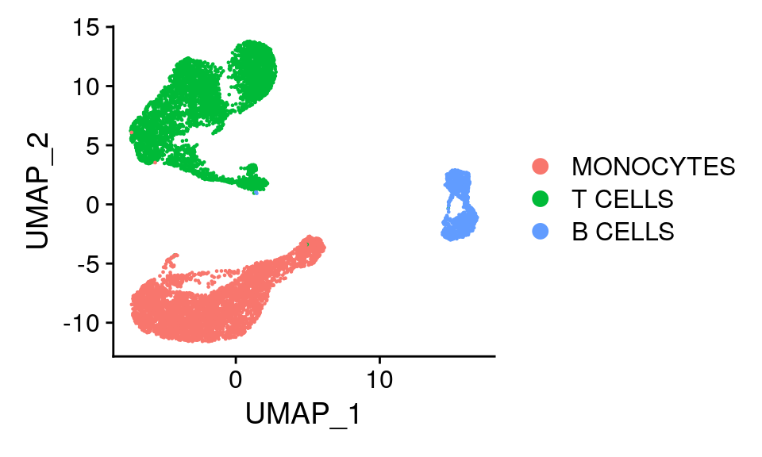

```r
DimPlot(s)
```

## Testing for differential expression

### Each group vs rest (default)

```r
de_results <- findDE(object = s)
```

```
#> group_column argument is not set - will use SeuratObject::Idents()
#> No replicates specified - will assign cells randomly to pseudoreplicates
#> Doing 3 comparisons
```

The output is one large data frame with the results for all three comparisons for all genes. The order of the output is by comparison, then by p-value, then by test statistic. Ordering can be turned off with `order_results = FALSE`

```r
head(de_results) %>%
  DT::datatable() %>%
  DT::formatSignif(columns = 2:8)
```

|  | feature | ave_expr | log_fc | stat | pvalue | padj | rate1 | rate2 | group1 | group2 |
| --- | --- | --- | --- | --- | --- | --- | --- | --- | --- | --- |
| 1 | CTSS | 11.1640679979409 | 4.70908146097954 | 51202.789928531 | 5.68009114913819e-48 | 2.07897016149607e-43 | 1 | 0.484694801666365 | MONOCYTES | not MONOCYTES |
| 2 | TYMP | 9.80107378706149 | 4.96943922459173 | 40251.1016070502 | 1.75455573242014e-46 | 2.87996551258983e-42 | 0.997529755221199 | 0.197246875566021 | MONOCYTES | not MONOCYTES |
| 3 | FTL | 12.7550507026195 | 2.91132785438024 | 39421.9243371461 | 2.36056297307983e-46 | 2.87996551258983e-42 | 1 | 0.988770150335084 | MONOCYTES | not MONOCYTES |
| 4 | S100A9 | 12.9945740425985 | 7.37438700041868 | 38495.3736241333 | 3.31313265013348e-46 | 3.03159920318839e-42 | 0.99393667190658 | 0.286904546277848 | MONOCYTES | not MONOCYTES |
| 5 | IFI30 | 9.39214513480621 | 4.98497404451093 | 33415.9175620165 | 2.4894594324238e-45 | 1.82233409372287e-41 | 0.994161239613744 | 0.124071726136569 | MONOCYTES | not MONOCYTES |
| 6 | S100A8 | 11.8593828242549 | 7.41796308349299 | 32576.6475194075 | 3.57715558322267e-45 | 2.18212452502555e-41 | 0.95396362003144 | 0.153233109943851 | MONOCYTES | not MONOCYTES |

There are as many rows per comparison, as there were genes in the input

```r
table(paste(de_results$group1, de_results$group2, sep = ' vs '))
```

```
#>
#>     B CELLS vs not B CELLS MONOCYTES vs not MONOCYTES
#>                      36601                      36601
#>     T CELLS vs not T CELLS
#>                      36601
```

The output contains the following columns

- **feature** the gene (as given by rownames of input)
- **ave_expr** average expression of gene (renamed method specific values; edger: logCPM, deseq: baseMean, limma: Amean)
- **log_fc** log fold-change (renamed method specific values; edger: logFC, deseq: log2FoldChange, limma: LogFC)
- **stat** test statistic (renamed method specific values; edger: F, deseq: stat, limma: lods)
- **pvalue** test p-value
- **padj** adjusted p-value (FDR)
- **rate1** detection rate in group one (fraction of cells with non-zero counts)
- **rate2** detection rate in group two (fraction of cells with non-zero counts)
- **group1** comparison group one
- **group2** comparison group two

The log fold-change values are estimates of the form log2(group1/group2) - details will depend on the method chosen.

We can plot the log fold-change vs FDR for each comparison.

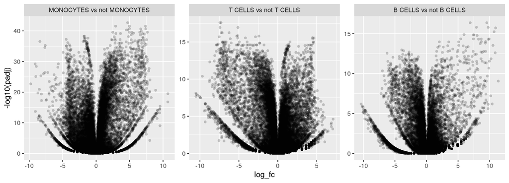

```r
de_results$comp <- paste(de_results$group1, de_results$group2, sep = ' vs ')
de_results$comp <- factor(de_results$comp, levels = unique(de_results$comp))
ggplot(de_results, aes(log_fc, -log10(padj))) +
  geom_point(shape = 16, alpha = 0.2) +
  facet_wrap(~ comp, scales = 'free')
```

For a given comparison, the genes higher in the first group will be assigned positive fold-changes. Below we mark the top 5 per comparison, ranked by p-value (the default output of `findDE()`).

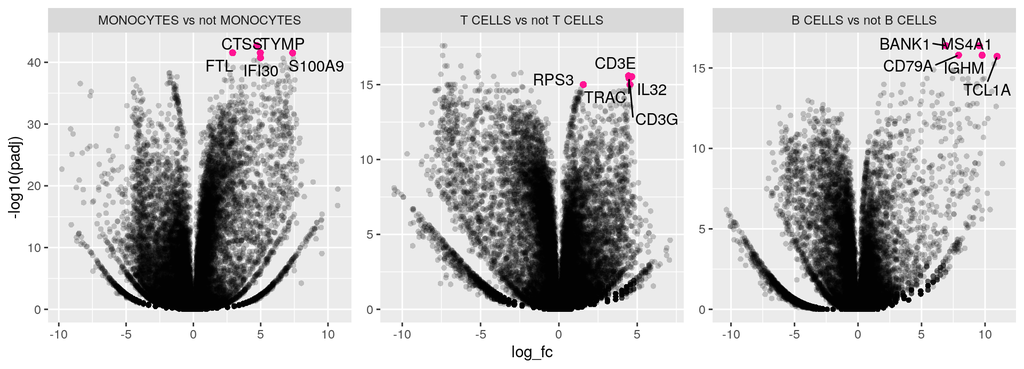

```r
top_DE <- filter(de_results, log_fc > 0) %>%
      group_by(group1) %>%
      slice_head(n = 5)
ggplot(de_results, aes(log_fc, -log10(padj))) +
  geom_point(shape = 16, alpha = 0.2) +
  geom_point(data = top_DE, shape = 16, size = 2, color = 'deeppink') +
  geom_text_repel(data = top_DE, aes(label = feature)) +
  facet_wrap(~ comp, scales = 'free')
```

### One group vs another

To compare two specific groups, use a character vector of length two as the `'compare'` argument.

```r
de_results <- findDE(object = s, compare = c('T CELLS', 'B CELLS'))
```

```
#> group_column argument is not set - will use SeuratObject::Idents()
#> No replicates specified - will assign cells randomly to pseudoreplicates
#> Doing 1 comparisons
```

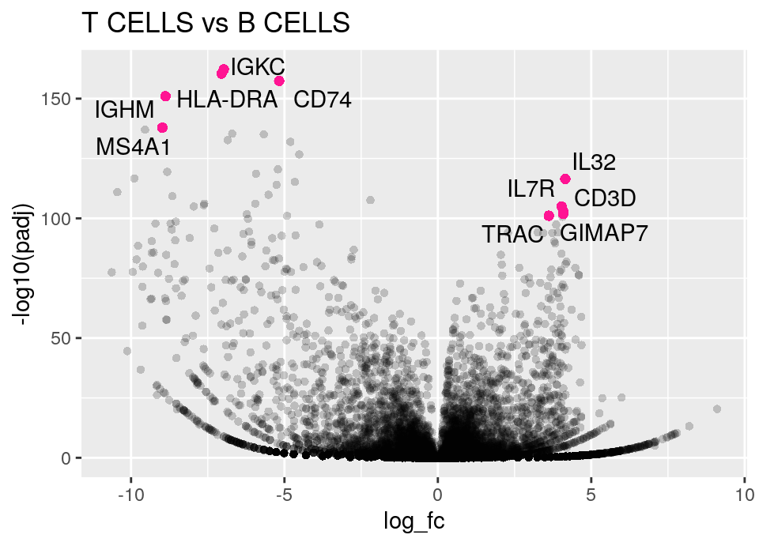

```r
top_DE <- filter(de_results, log_fc != 0) %>%
  group_by(sign(log_fc)) %>%
  slice_head(n = 5)
ggplot(de_results, aes(log_fc, -log10(padj))) +
  geom_point(shape = 16, alpha = 0.2) +
  geom_point(data = top_DE, shape = 16, size = 2, color = 'deeppink') +
  geom_text_repel(data = top_DE, aes(label = feature)) +
  ggtitle('T CELLS vs B CELLS')
```

### Non-Seurat input

An example of a count matrix and meta data as input.

```r
# extract the counts and meta data from our example Seurat object
counts <- s$RNA@counts
meta_data <- data.frame(celltype = Idents(s))
# use matrix and data frame as input to findDE
de_results <- findDE(object = counts, meta_data = meta_data,
                     group_column = 'celltype', compare = c('T CELLS', 'B CELLS'))
```

```
#> No replicates specified - will assign cells randomly to pseudoreplicates
#> Doing 1 comparisons
```

```r
head(de_results) %>%
  DT::datatable() %>%
  DT::formatSignif(columns = 2:8)
```

|  | feature | ave_expr | log_fc | stat | pvalue | padj | rate1 | rate2 | group1 | group2 |
| --- | --- | --- | --- | --- | --- | --- | --- | --- | --- | --- |
| 1 | HLA-DRA | 10.9819580110666 | -7.03815298093124 | 23508.3698319983 | 2.72764945946697e-20 | 9.98346978659504e-16 | 0.0979301135099043 | 0.999027237354086 | T CELLS | B CELLS |
| 2 | CD74 | 11.2005781891003 | -5.16180266089267 | 20412.1181424499 | 6.10902076376844e-20 | 1.07514387075461e-15 | 0.432895615401736 | 1 | T CELLS | B CELLS |
| 3 | IGKC | 11.5948269990616 | -6.96542486190611 | 19143.2750073042 | 8.81241390198032e-20 | 1.07514387075461e-15 | 0.155797907856666 | 0.744163424124514 | T CELLS | B CELLS |
| 4 | MS4A1 | 8.67171281373401 | -8.96980264800283 | 17297.7987338532 | 1.57191465044623e-19 | 1.43834120302456e-15 | 0.00934787447139996 | 0.994163424124514 | T CELLS | B CELLS |
| 5 | HLA-DPB1 | 8.63542677197209 | -4.50590779552173 | 13163.9117488138 | 7.4722089019647e-19 | 5.4698063604162e-15 | 0.166258624527042 | 0.992217898832685 | T CELLS | B CELLS |
| 6 | IGLC2 | 8.89041398496054 | -9.53193675321868 | 12413.4177755285 | 1.04460508988605e-18 | 6.37226514915324e-15 | 0.00934787447139996 | 0.39591439688716 | T CELLS | B CELLS |

An example using a SingleCellExperiment as input.

```r
sce <- SingleCellExperiment::SingleCellExperiment(list(counts=counts))
SingleCellExperiment::colLabels(sce) <- meta_data$celltype
de_results <- findDE(object = sce, compare = c('T CELLS', 'B CELLS'))
```

```
#> group_column argument is not set - will use SingleCellExperiment::colLabels()
#> No replicates specified - will assign cells randomly to pseudoreplicates
#> Doing 1 comparisons
```

```r
head(de_results) %>%
  DT::datatable() %>%
  DT::formatSignif(columns = 2:8)
```

|  | feature | ave_expr | log_fc | stat | pvalue | padj | rate1 | rate2 | group1 | group2 |
| --- | --- | --- | --- | --- | --- | --- | --- | --- | --- | --- |
| 1 | IGKC | 11.5051309035677 | -6.97553467978156 | 31342.0638580692 | 9.22074940122974e-29 | 3.3748864883441e-24 | 0.155797907856666 | 0.744163424124514 | T CELLS | B CELLS |
| 2 | CD74 | 11.0951704054994 | -5.17159600771423 | 22538.5986447252 | 1.44213041297878e-27 | 2.63917076227181e-23 | 0.432895615401736 | 1 | T CELLS | B CELLS |
| 3 | CD79A | 8.57522947421133 | -6.70297524515389 | 19802.7615551276 | 4.24257574010058e-27 | 5.17608382211404e-23 | 0.0567549521477854 | 0.997081712062257 | T CELLS | B CELLS |
| 4 | HLA-DRA | 10.8579443214102 | -7.0477941327375 | 12907.9257374823 | 1.5034556214085e-25 | 1.36872394551759e-21 | 0.0979301135099043 | 0.999027237354086 | T CELLS | B CELLS |
| 5 | HLA-DPA1 | 8.71082632494833 | -4.80740989984434 | 12574.57871425 | 1.86979036845659e-25 | 1.36872394551759e-21 | 0.147340307144447 | 0.996108949416342 | T CELLS | B CELLS |
| 6 | HLA-DQA1 | 8.16324265170835 | -6.84863838367994 | 11098.3066248535 | 5.29384904137473e-25 | 3.22933614605594e-21 | 0.0309370131315379 | 0.989299610894942 | T CELLS | B CELLS |

## Finding markers

To quickly find all marker features for a given object, `DElegate` provides the convenience function `FindAllMarkers2()` - a light wrapper around `findDE(compare = 'each_vs_rest')` that filters for positive fold-change and orders the results by p-value and test statistic. Note that by default this function applies a post-test filter that removes genes with low detection rate (`min_rate = 0.05`) and low log fold-change (`min_fc = 1`).

```r
marker_results <- FindAllMarkers2(object = s)
```

```
#> group_column argument is not set - will use SeuratObject::Idents()
#> No replicates specified - will assign cells randomly to pseudoreplicates
#> Doing 3 comparisons
```

```r
filter(marker_results, feature_rank < 6) %>%
  DT::datatable() %>%
  DT::formatSignif(columns = 2:8)
```

|  | feature | ave_expr | log_fc | stat | pvalue | padj | rate1 | rate2 | group1 | feature_rank |
| --- | --- | --- | --- | --- | --- | --- | --- | --- | --- | --- |
| 1 | CTSS | 11.1702627677461 | 4.71464918464008 | 45939.0195134561 | 3.1489676909143e-35 | 7.64569355353991e-32 | 1 | 0.484694801666365 | MONOCYTES | 1 |
| 2 | FCN1 | 9.96206480393403 | 6.94039982503957 | 40313.1340448021 | 1.16910875682079e-34 | 1.41929803078044e-31 | 0.991690994834943 | 0.0465495381271509 | MONOCYTES | 2 |
| 3 | LYZ | 12.4464389504493 | 7.18812882049836 | 36647.0496106497 | 3.04517695951654e-34 | 2.46456321923539e-31 | 0.999775432292836 | 0.224596993298316 | MONOCYTES | 3 |
| 4 | PSAP | 9.63135709925171 | 4.50524384118554 | 32924.0052514428 | 8.92773560483346e-34 | 5.41913551213391e-31 | 0.997978890635527 | 0.280202861800398 | MONOCYTES | 4 |
| 5 | TYMP | 9.81011432078102 | 4.97511099119195 | 31666.3711276146 | 1.3199455169774e-33 | 6.40965543044224e-31 | 0.997529755221199 | 0.197246875566021 | MONOCYTES | 5 |
| 6 | CD3E | 8.19464965005306 | 4.45548679422909 | 24271.9789182525 | 5.48772945944601e-23 | 4.38360175797625e-20 | 0.963276207433786 | 0.076810800948732 | T CELLS | 1 |
| 7 | TRAC | 8.38441581510757 | 4.48947781785001 | 21263.8086396996 | 1.31639539357239e-22 | 4.38360175797625e-20 | 0.939016247496105 | 0.0897646414887794 | T CELLS | 2 |
| 8 | IL32 | 9.42826614270892 | 4.6588870923235 | 21024.6201797038 | 1.41864134562338e-22 | 4.38360175797625e-20 | 0.969508123748053 | 0.0966976829045795 | T CELLS | 3 |
| 9 | RPS3 | 12.0459643186993 | 1.56657742558594 | 17896.4675915977 | 4.11585618303024e-22 | 9.53849670417258e-20 | 0.999109726240819 | 0.997628170041963 | T CELLS | 4 |
| 10 | CD3G | 8.04292691598928 | 4.53980539272245 | 15695.2913447282 | 9.80162601103317e-22 | 1.81722146244555e-19 | 0.931448920543067 | 0.0704251049078635 | T CELLS | 5 |

[output cut: 5 more lines]

## Parallelization

`DElegate` supports parallelization via the `future` package. For example, to use the multicore strategy with 12 workers you may call `future::plan(strategy = 'future::multicore', workers = 12)` before DE testing. See more details at the [`future` website](https://future.futureverse.org)

Note that every comparison is run single-threaded, but multiple comparisons will be done in parallel.

**Trouble shooting:** You may get an error regarding `future.globals.maxSize`, the maximum allowed total size of global variables. The default value is 500 MiB and may be too small. You may increase it, for example to 8GB, using `options(future.globals.maxSize = 8 * 10^9)`.

## Progress updates

For reporting progress updates, `DElegate` relies on the `progressr` package. By default no progress updates are rendered, but may be turned on in an R session: `progressr::handlers(global = TRUE)` and its default presentation modified (e.g. `progressr::handlers(progressr::handler_progress)`). See more details at the [`progressr` website](https://progressr.futureverse.org)

## Example: Seurat DE vignette

Here we perform the same DE tasks as in the [Seurat DE vignette](https://satijalab.org/seurat/articles/de_vignette.html).

```r
library(Seurat)
library(SeuratData)
pbmc <- LoadData("pbmc3k", type = "pbmc3k.final")
```

Find differentially expressed features between CD14+ and FCGR3A+ Monocytes (this is the alternative to `Seurat::FindMarkers(pbmc, ident.1 = "CD14+ Mono", ident.2 = "FCGR3A+ Mono")`)

```r
de_res <- findDE(object = pbmc, compare = c("CD14+ Mono", "FCGR3A+ Mono"))
```

```
#> group_column argument is not set - will use SeuratObject::Idents()
#> No replicates specified - will assign cells randomly to pseudoreplicates
#> Doing 1 comparisons
```

```r
head(de_res, 10) %>%
  DT::datatable() %>%
  DT::formatSignif(columns = 2:8)
```

|  | feature | ave_expr | log_fc | stat | pvalue | padj | rate1 | rate2 | group1 | group2 |
| --- | --- | --- | --- | --- | --- | --- | --- | --- | --- | --- |
| 1 | S100A9 | 12.8742901751178 | 3.59408611217452 | 1770.10370573273 | 4.47512133482567e-43 | 4.86396736452051e-39 | 0.995833333333333 | 0.87037037037037 | CD14+ Mono | FCGR3A+ Mono |
| 2 | S100A8 | 11.9182887291133 | 4.23340733991921 | 1739.37763981755 | 7.09343351979074e-43 | 4.86396736452051e-39 | 0.975 | 0.5 | CD14+ Mono | FCGR3A+ Mono |
| 3 | LYZ | 13.5065570294045 | 2.89785899499131 | 1458.60418251359 | 7.1785728044831e-41 | 3.28156491468938e-37 | 1 | 0.987654320987654 | CD14+ Mono | FCGR3A+ Mono |
| 4 | FCGR3A | 10.0589765818669 | -4.5709961630166 | 856.125387747241 | 6.91671751961837e-35 | 2.37139660160116e-31 | 0.13125 | 0.975308641975309 | CD14+ Mono | FCGR3A+ Mono |
| 5 | LGALS2 | 9.99717500361541 | 3.76434948103796 | 515.506308758252 | 2.31599176091949e-29 | 6.35230220184997e-26 | 0.908333333333333 | 0.265432098765432 | CD14+ Mono | FCGR3A+ Mono |
| 6 | CD14 | 8.69699085631621 | 3.83601843222912 | 303.484274009075 | 7.19616877859022e-24 | 1.6448043104931e-20 | 0.666666666666667 | 0.154320987654321 | CD14+ Mono | FCGR3A+ Mono |
| 7 | MS4A6A | 8.74529416747784 | 3.57913070331731 | 297.391116459779 | 1.14812416573677e-23 | 2.2493392584163e-20 | 0.685416666666667 | 0.185185185185185 | CD14+ Mono | FCGR3A+ Mono |
| 8 | IFITM2 | 10.9308733951966 | -1.91316785143312 | 290.877054059825 | 1.90911704425597e-23 | 2.95832223448494e-20 | 0.677083333333333 | 1 | CD14+ Mono | FCGR3A+ Mono |
| 9 | GPX1 | 10.1551184632266 | 2.24532506370565 | 290.664066724475 | 1.94143941303518e-23 | 2.95832223448494e-20 | 0.922916666666667 | 0.654320987654321 | CD14+ Mono | FCGR3A+ Mono |
| 10 | CCL3 | 8.70792664575388 | 3.35589513400454 | 271.748126274501 | 9.00324078121268e-23 | 1.23470444073551e-19 | 0.389583333333333 | 0.160493827160494 | CD14+ Mono | FCGR3A+ Mono |

We can omit the second part of the comparison argument to find CD14+ Mono markers relative to all other cells (alternative to `Seurat::FindMarkers(pbmc, ident.1 = "CD14+ Mono", ident.2 = NULL, only.pos = TRUE)`).

```r
de_res <- findDE(object = pbmc, compare = "CD14+ Mono")
```

```
#> group_column argument is not set - will use SeuratObject::Idents()
#> No replicates specified - will assign cells randomly to pseudoreplicates
#> Doing 1 comparisons
```

```r
# exclude negative log fold-change
filter(de_res, log_fc > 0) %>% head(10) %>%
  DT::datatable() %>%
  DT::formatSignif(columns = 2:8)
```

|  | feature | ave_expr | log_fc | stat | pvalue | padj | rate1 | rate2 | group1 | group2 |
| --- | --- | --- | --- | --- | --- | --- | --- | --- | --- | --- |
| 1 | LYZ | 13.318658183105 | 4.27566426495922 | 3992.19001499778 | 2.19023004103002e-14 | 2.3095808398438e-10 | 1 | 0.516682113067655 | CD14+ Mono | not CD14+ Mono |
| 2 | S100A8 | 11.7661741398109 | 6.2823688310825 | 3663.30556763582 | 3.36820889579087e-14 | 2.3095808398438e-10 | 0.975 | 0.121408711770158 | CD14+ Mono | not CD14+ Mono |
| 3 | LGALS2 | 9.77436251218782 | 5.02693074202479 | 3086.14984310035 | 7.94314774057478e-14 | 3.63107760380808e-10 | 0.908333333333333 | 0.0593141797961075 | CD14+ Mono | not CD14+ Mono |
| 4 | S100A9 | 12.7015885486832 | 5.79614729681223 | 2865.47749218425 | 1.15125375394141e-13 | 3.94707349538813e-10 | 0.995833333333333 | 0.215477293790547 | CD14+ Mono | not CD14+ Mono |
| 5 | CD14 | 8.31874380173742 | 5.69231210534471 | 1617.93379272652 | 2.0018351287242e-12 | 4.57552782588728e-09 | 0.666666666666667 | 0.0278035217794254 | CD14+ Mono | not CD14+ Mono |
| 6 | S100A6 | 11.4594175988808 | 1.97111059596657 | 1557.73489633099 | 2.4187068704505e-12 | 4.73859228876546e-09 | 0.995833333333333 | 0.735403151065802 | CD14+ Mono | not CD14+ Mono |
| 7 | GSTP1 | 10.0156530189519 | 2.7670426761901 | 1408.91238051753 | 3.99081345612096e-12 | 6.08111285969365e-09 | 0.94375 | 0.352177942539388 | CD14+ Mono | not CD14+ Mono |
| 8 | MS4A6A | 8.39255653826694 | 4.66788059888676 | 1303.67498683712 | 5.87621904745309e-12 | 8.05864680167717e-09 | 0.685416666666667 | 0.041241890639481 | CD14+ Mono | not CD14+ Mono |
| 9 | TYROBP | 11.4723956426892 | 2.89369944235663 | 1133.92389170286 | 1.17713489163508e-11 | 1.46756617308032e-08 | 0.99375 | 0.265060240963855 | CD14+ Mono | not CD14+ Mono |
| 10 | FTL | 14.2975451189994 | 2.28228501583826 | 1008.93553532631 | 2.10458509673881e-11 | 2.22017538589816e-08 | 1 | 0.987488415199259 | CD14+ Mono | not CD14+ Mono |

Note that we do not suggest prefiltering. A postfilter using log fold-change and/or detection rate may be appropriate instead.

Just as in the examples above, we can find markers for all groups at once with `FindAllMarkers2`. By default this wrapper around `findDE()` removes genes with detection rate < 0.05 (maximum across groups compared) and low log fold-change (< 1). This is an alternative to `Seurat::FindAllMarkers(pbmc)`.

```r
marker_results <- FindAllMarkers2(object = pbmc)
```

```
#> group_column argument is not set - will use SeuratObject::Idents()
#> No replicates specified - will assign cells randomly to pseudoreplicates
#> Doing 9 comparisons
```

```r
filter(marker_results, feature_rank < 6) %>%
  DT::datatable() %>%
  DT::formatSignif(columns = 2:8)
```

|  | feature | ave_expr | log_fc | stat | pvalue | padj | rate1 | rate2 | group1 | feature_rank |
| --- | --- | --- | --- | --- | --- | --- | --- | --- | --- | --- |
| 1 | CD3D | 9.59779947426002 | 1.21069273810011 | 655.971685311166 | 6.09538128908605e-09 | 1.03011943785554e-06 | 0.837876614060258 | 0.405976300875837 | Naive CD4 T | 1 |
| 2 | PIK3IP1 | 7.51978103824302 | 1.69766931906521 | 430.169399657829 | 3.20293832761229e-08 | 2.50370862194767e-06 | 0.437589670014347 | 0.184956208140134 | Naive CD4 T | 2 |
| 3 | CCR7 | 7.39149230687081 | 2.51188040652959 | 385.050380595056 | 4.94337298597694e-08 | 2.50370862194767e-06 | 0.436154949784792 | 0.110252447192169 | Naive CD4 T | 3 |
| 4 | LDHB | 10.018095805813 | 1.29570796871343 | 367.609571311828 | 5.92593756674005e-08 | 2.50370862194767e-06 | 0.901004304160689 | 0.594023699124163 | Naive CD4 T | 4 |
| 5 | PRKCQ-AS1 | 6.91942322536701 | 2.09096647337783 | 280.337347955237 | 1.70458767526178e-07 | 5.09993695799448e-06 | 0.33142037302726 | 0.110252447192169 | Naive CD4 T | 5 |
| 6 | IL32 | 10.2228797704811 | 1.38098478879602 | 637.784264923714 | 3.58398991999707e-09 | 5.66270407359537e-07 | 0.94824016563147 | 0.463573085846868 | Memory CD4 T | 1 |
| 7 | TNFRSF4 | 5.61619065246659 | 3.3237021819763 | 338.509226140055 | 4.81636120521018e-08 | 3.80492535211604e-06 | 0.213250517598344 | 0.0236658932714617 | Memory CD4 T | 2 |
| 8 | CD3D | 9.63419819651945 | 1.1188176422016 | 283.345950494606 | 9.93461232964073e-08 | 4.99521573237211e-06 | 0.919254658385093 | 0.430626450116009 | Memory CD4 T | 3 |
| 9 | LTB | 11.1576548657476 | 1.4313390873011 | 266.987489494404 | 1.26461157781573e-07 | 4.99521573237211e-06 | 0.981366459627329 | 0.641763341067285 | Memory CD4 T | 4 |
| 10 | IL7R | 9.02407420646865 | 1.41265470257571 | 228.759730935852 | 2.3631186879194e-07 | 7.46745505382532e-06 | 0.747412008281574 | 0.325290023201856 | Memory CD4 T | 5 |

[output cut: 35 more lines]

## Session info

> *NOTE:* This document was generated with `DElegate` version 1.0.0